# Part I - (Prosper Loan Data Exploration)

## Introduction

This document looks to explore a dataset containing loan information for approximately 114,000 loans analysing metrixes such as interest rate, the status of repayment among other data points.

## Preliminary Wrangling

This data set contains 113,937 loans with 81 variables on each loan, including loan amount, borrower rate (or interest rate), current loan status, borrower income, and many others

```python
# import all packages and set plots to be embedded inline
import numpy as np
import pandas as pd
import matplotlib.pyplot as plt
import seaborn as sb

%matplotlib inline
```

Loading in the dataset into a pandas dataframe, to get key statistics and insight

```python
df_pl = pd.read_csv("prosperLoanData.csv")
```

```python
# high-level overview of data shape and composition
print(df_pl.info)
print(df_pl.shape)
print(df_pl.dtypes)
print(df_pl.head(10))
```

[output not shown]

[output cut: 500 more lines]

Streamlining for the columns that are useful for the pupose of this analysis

```python
df_pl.columns
```

```
Index(['ListingKey', 'ListingNumber', 'ListingCreationDate', 'CreditGrade',
       'Term', 'LoanStatus', 'ClosedDate', 'BorrowerAPR', 'BorrowerRate',
       'LenderYield', 'EstimatedEffectiveYield', 'EstimatedLoss',
       'EstimatedReturn', 'ProsperRating (numeric)', 'ProsperRating (Alpha)',
       'ProsperScore', 'ListingCategory (numeric)', 'BorrowerState',
       'Occupation', 'EmploymentStatus', 'EmploymentStatusDuration',
       'IsBorrowerHomeowner', 'CurrentlyInGroup', 'GroupKey',
       'DateCreditPulled', 'CreditScoreRangeLower', 'CreditScoreRangeUpper',
       'FirstRecordedCreditLine', 'CurrentCreditLines', 'OpenCreditLines',
       'TotalCreditLinespast7years', 'OpenRevolvingAccounts',
       'OpenRevolvingMonthlyPayment', 'InquiriesLast6Months', 'TotalInquiries',
       'CurrentDelinquencies', 'AmountDelinquent', 'DelinquenciesLast7Years',
       'PublicRecordsLast10Years', 'PublicRecordsLast12Months',
       'RevolvingCreditBalance', 'BankcardUtilization',
       'AvailableBankcardCredit', 'TotalTrades',
       'TradesNeverDelinquent (percentage)', 'TradesOpenedLast6Months',
       'DebtToIncomeRatio', 'IncomeRange', 'IncomeVerifiable',
       'StatedMonthlyIncome', 'LoanKey', 'TotalProsperLoans',
       'TotalProsperPaymentsBilled', 'OnTimeProsperPayments',
       'ProsperPaymentsLessThanOneMonthLate',
       'ProsperPaymentsOneMonthPlusLate', 'ProsperPrincipalBorrowed',
       'ProsperPrincipalOutstanding', 'ScorexChangeAtTimeOfListing',
       'LoanCurrentDaysDelinquent', 'LoanFirstDefaultedCycleNumber',
       'LoanMonthsSinceOrigination', 'LoanNumber', 'LoanOriginalAmount',
       'LoanOriginationDate', 'LoanOriginationQuarter', 'MemberKey',
       'MonthlyLoanPayment', 'LP_CustomerPayments',
       'LP_CustomerPrincipalPayments', 'LP_InterestandFees', 'LP_ServiceFees',
       'LP_CollectionFees', 'LP_GrossPrincipalLoss', 'LP_NetPrincipalLoss',
       'LP_NonPrincipalRecoverypayments', 'PercentFunded', 'Recommendations',
       'InvestmentFromFriendsCount', 'InvestmentFromFriendsAmount',
       'Investors'],
      dtype='object')
```

```python
list_columns = ["LoanStatus","LenderYield","ProsperRating (numeric)","ProsperScore","ListingCategory (numeric)","Occupation","EmploymentStatus","IsBorrowerHomeowner",
               "CurrentDelinquencies","AmountDelinquent","DelinquenciesLast7Years","IncomeRange","TotalProsperLoans","OnTimeProsperPayments","BorrowerState"]
```

```python
df_pl = df_pl[list_columns]
```

checking to see if the streamline was a success

```python
df_pl.sample(5)
```

|  | LoanStatus | LenderYield | ProsperRating (numeric) | ProsperScore | ListingCategory (numeric) | Occupation | EmploymentStatus | IsBorrowerHomeowner | CurrentDelinquencies | AmountDelinquent | DelinquenciesLast7Years | IncomeRange | TotalProsperLoans | OnTimeProsperPayments | BorrowerState |
| --- | --- | --- | --- | --- | --- | --- | --- | --- | --- | --- | --- | --- | --- | --- | --- |
| 37934 | Completed | 0.2475 | 3.0 | 8.0 | 1 | Other | Full-time | False | 0.0 | 0.0 | 0.0 | $50,000-74,999 | 1.0 | 23.0 | CA |
| 60743 | Current | 0.1450 | 5.0 | 6.0 | 1 | Professional | Employed | True | 0.0 | 0.0 | 0.0 | $100,000+ | NaN | NaN | TX |
| 18047 | Completed | 0.1590 | 4.0 | 9.0 | 1 | Car Dealer | Full-time | True | 0.0 | 0.0 | 0.0 | $50,000-74,999 | NaN | NaN | CA |
| 74043 | Completed | 0.0855 | 7.0 | 10.0 | 1 | Executive | Employed | False | 0.0 | 0.0 | 0.0 | $100,000+ | NaN | NaN | NY |
| 97184 | Defaulted | 0.3400 | NaN | NaN | 1 | Laborer | Full-time | False | 4.0 | 2469.0 | 13.0 | $25,000-49,999 | NaN | NaN | MI |

```python
df_pl.shape
```

```
(113937, 15)
```

For the purpose of this analysis, I will neeed features like Employment status , Total Prosper loans, current deliquencies,listingCategory speaks to to be able to predict the purpose of the loan

# Cleaning the dataframe

```python
df1 = df_pl.copy()
```

Dropping the missing datacells

```python
df1.dropna(inplace = True)
```

```python
df1.shape
```

```
(19771, 15)
```

```python
df1
```

|  | LoanStatus | LenderYield | ProsperRating (numeric) | ProsperScore | ListingCategory (numeric) | Occupation | EmploymentStatus | IsBorrowerHomeowner | CurrentDelinquencies | AmountDelinquent | DelinquenciesLast7Years | IncomeRange | TotalProsperLoans | OnTimeProsperPayments | BorrowerState |
| --- | --- | --- | --- | --- | --- | --- | --- | --- | --- | --- | --- | --- | --- | --- | --- |
| 4 | Current | 0.1985 | 3.0 | 4.0 | 2 | Executive | Employed | True | 0.0 | 0.0 | 0.0 | $100,000+ | 1.0 | 11.0 | MN |
| 16 | Current | 0.2709 | 2.0 | 4.0 | 6 | Professional | Full-time | True | 1.0 | 2469.0 | 12.0 | $75,000-99,999 | 3.0 | 67.0 | CA |
| 19 | Current | 0.2125 | 3.0 | 8.0 | 1 | Laborer | Employed | False | 0.0 | 0.0 | 0.0 | $25,000-49,999 | 1.0 | 12.0 | OR |
| 33 | Completed | 0.0685 | 7.0 | 10.0 | 7 | Other | Employed | False | 0.0 | 0.0 | 0.0 | $100,000+ | 1.0 | 8.0 | IL |
| 47 | Current | 0.1199 | 6.0 | 8.0 | 1 | Professional | Employed | True | 0.0 | 0.0 | 0.0 | $50,000-74,999 | 3.0 | 20.0 | CO |
| 54 | Current | 0.1752 | 5.0 | 5.0 | 2 | Executive | Employed | True | 0.0 | 0.0 | 2.0 | $100,000+ | 1.0 | 8.0 | WI |
| 58 | Current | 0.1419 | 5.0 | 6.0 | 1 | Clergy | Employed | False | 0.0 | 0.0 | 0.0 | $50,000-74,999 | 1.0 | 1.0 | IL |
| 61 | Current | 0.1174 | 5.0 | 8.0 | 19 | Analyst | Employed | True | 20.0 | 72705.0 | 72.0 | $75,000-99,999 | 2.0 | 4.0 | DE |
| 67 | Completed | 0.2569 | 2.0 | 3.0 | 1 | Professional | Employed | False | 0.0 | 0.0 | 0.0 | $50,000-74,999 | 1.0 | 12.0 | CA |
| 69 | Current | 0.1039 | 6.0 | 11.0 | 1 | Investor | Self-employed | True | 0.0 | 0.0 | 0.0 | $25,000-49,999 | 3.0 | 16.0 | IL |
| 77 | Completed | 0.0999 | 5.0 | 8.0 | 6 | Analyst | Full-time | True | 0.0 | 0.0 | 0.0 | $75,000-99,999 | 1.0 | 6.0 | VA |
| 82 | Past Due (16-30 days) | 0.2832 | 2.0 | 2.0 | 7 | Other | Employed | False | 0.0 | 0.0 | 0.0 | $50,000-74,999 | 1.0 | 6.0 | NY |
| 87 | Completed | 0.2899 | 2.0 | 3.0 | 1 | Professional | Employed | True | 0.0 | 0.0 | 30.0 | $25,000-49,999 | 1.0 | 10.0 | GA |
| 97 | Current | 0.1839 | 4.0 | 6.0 | 7 | Sales - Retail | Employed | False | 0.0 | 0.0 | 0.0 | $1-24,999 | 1.0 | 32.0 | GA |
| 98 | Current | 0.1255 | 5.0 | 9.0 | 1 | Computer Programmer | Employed | True | 2.0 | 0.0 | 10.0 | $50,000-74,999 | 1.0 | 35.0 | VA |
| 99 | Current | 0.0769 | 7.0 | 10.0 | 2 | Other | Other | False | 0.0 | 0.0 | 0.0 | $25,000-49,999 | 1.0 | 14.0 | MO |
| 100 | Chargedoff | 0.3034 | 1.0 | 3.0 | 13 | Other | Not employed | False | 0.0 | 0.0 | 0.0 | Not employed | 1.0 | 7.0 | CA |
| 102 | Completed | 0.1238 | 6.0 | 9.0 | 1 | Professional | Full-time | True | 0.0 | 0.0 | 1.0 | $100,000+ | 1.0 | 14.0 | MD |
| 103 | Chargedoff | 0.2187 | 3.0 | 2.0 | 3 | Truck Driver | Self-employed | True | 0.0 | 0.0 | 0.0 | $50,000-74,999 | 1.0 | 28.0 | CO |
| 106 | Current | 0.1519 | 5.0 | 6.0 | 1 | Other | Employed | False | 1.0 | 134.0 | 0.0 | $50,000-74,999 | 1.0 | 5.0 | IL |
| 109 | Completed | 0.1134 | 4.0 | 9.0 | 1 | Police Officer/Correction Officer | Full-time | True | 0.0 | 0.0 | 0.0 | $50,000-74,999 | 1.0 | 22.0 | IL |
| 110 | Completed | 0.3000 | 1.0 | 5.0 | 7 | Nurse (RN) | Full-time | True | 1.0 | 71.0 | 0.0 | $50,000-74,999 | 1.0 | 4.0 | PA |
| 124 | Current | 0.1669 | 5.0 | 6.0 | 1 | Construction | Employed | True | 0.0 | 0.0 | 0.0 | $75,000-99,999 | 2.0 | 12.0 | LA |
| 133 | Current | 0.1264 | 6.0 | 8.0 | 11 | Other | Employed | False | 0.0 | 0.0 | 0.0 | $25,000-49,999 | 1.0 | 24.0 | MD |
| 138 | Defaulted | 0.2899 | 2.0 | 3.0 | 6 | Military Enlisted | Employed | True | 2.0 | 1890.0 | 23.0 | $25,000-49,999 | 1.0 | 3.0 | KY |
| 139 | Past Due (1-15 days) | 0.2899 | 2.0 | 3.0 | 2 | Other | Other | False | 0.0 | 0.0 | 20.0 | $1-24,999 | 1.0 | 10.0 | KY |
| 147 | Completed | 0.0612 | 7.0 | 10.0 | 6 | Professional | Full-time | False | 0.0 | 0.0 | 0.0 | $50,000-74,999 | 1.0 | 9.0 | OK |
| 149 | Current | 0.2404 | 2.0 | 2.0 | 1 | Professional | Employed | True | 0.0 | 0.0 | 23.0 | $75,000-99,999 | 1.0 | 1.0 | NY |
| 155 | Completed | 0.1730 | 5.0 | 7.0 | 3 | Computer Programmer | Employed | False | 0.0 | 0.0 | 0.0 | $75,000-99,999 | 1.0 | 4.0 | CA |
| 158 | Current | 0.0709 | 7.0 | 11.0 | 6 | Tradesman - Mechanic | Employed | False | 1.0 | 15599.0 | 5.0 | $75,000-99,999 | 1.0 | 15.0 | OR |
| ... | ... | ... | ... | ... | ... | ... | ... | ... | ... | ... | ... | ... | ... | ... | ... |
| 113781 | Current | 0.1214 | 5.0 | 8.0 | 3 | Truck Driver | Employed | False | 0.0 | 0.0 | 0.0 | $25,000-49,999 | 1.0 | 7.0 | FL |
| 113782 | Completed | 0.2640 | 3.0 | 7.0 | 2 | Professional | Full-time | True | 0.0 | 0.0 | 1.0 | $50,000-74,999 | 1.0 | 3.0 | AL |
| 113784 | Current | 0.0890 | 6.0 | 11.0 | 1 | Other | Employed | True | 0.0 | 0.0 | 0.0 | $100,000+ | 1.0 | 18.0 | CA |
| 113788 | Current | 0.1774 | 4.0 | 5.0 | 1 | Engineer - Electrical | Employed | True | 0.0 | 0.0 | 0.0 | $50,000-74,999 | 2.0 | 37.0 | VT |
| 113789 | Current | 0.1059 | 6.0 | 7.0 | 1 | Civil Service | Employed | True | 0.0 | 0.0 | 0.0 | $50,000-74,999 | 1.0 | 23.0 | MI |
| 113792 | Completed | 0.2187 | 3.0 | 3.0 | 1 | Sales - Commission | Self-employed | True | 0.0 | 0.0 | 17.0 | $100,000+ | 1.0 | 18.0 | MO |
| 113800 | Completed | 0.1159 | 4.0 | 5.0 | 1 | Skilled Labor | Employed | False | 0.0 | 0.0 | 0.0 | $75,000-99,999 | 1.0 | 1.0 | NJ |
| 113802 | Completed | 0.3077 | 1.0 | 2.0 | 1 | Engineer - Mechanical | Employed | False | 0.0 | 0.0 | 1.0 | $25,000-49,999 | 4.0 | 55.0 | OH |
| 113813 | Current | 0.2489 | 4.0 | 3.0 | 1 | Professional | Employed | True | 0.0 | 0.0 | 0.0 | $75,000-99,999 | 3.0 | 48.0 | FL |
| 113821 | Current | 0.1695 | 4.0 | 6.0 | 1 | Other | Employed | False | 0.0 | 0.0 | 0.0 | $50,000-74,999 | 1.0 | 11.0 | CA |
| 113840 | Defaulted | 0.1900 | 4.0 | 10.0 | 7 | Teacher's Aide | Full-time | False | 0.0 | 0.0 | 7.0 | $1-24,999 | 1.0 | 20.0 | NC |
| 113842 | Completed | 0.2875 | 1.0 | 2.0 | 1 | Fireman | Full-time | True | 0.0 | 0.0 | 0.0 | $75,000-99,999 | 1.0 | 11.0 | PA |
| 113844 | Current | 0.1199 | 6.0 | 10.0 | 7 | Other | Employed | False | 0.0 | 0.0 | 0.0 | $50,000-74,999 | 3.0 | 25.0 | FL |
| 113849 | Current | 0.1499 | 5.0 | 6.0 | 13 | Administrative Assistant | Employed | True | 0.0 | 0.0 | 0.0 | $25,000-49,999 | 1.0 | 1.0 | PA |
| 113855 | Current | 0.1089 | 6.0 | 11.0 | 3 | Food Service Management | Full-time | False | 0.0 | 0.0 | 0.0 | $75,000-99,999 | 1.0 | 33.0 | NY |
| 113860 | Current | 0.0999 | 5.0 | 8.0 | 1 | Analyst | Employed | False | 0.0 | 0.0 | 0.0 | $50,000-74,999 | 1.0 | 35.0 | CO |
| 113868 | Completed | 0.2900 | 3.0 | 8.0 | 1 | Professional | Full-time | True | 0.0 | 0.0 | 4.0 | $75,000-99,999 | 1.0 | 28.0 | WI |
| 113869 | Completed | 0.2120 | 4.0 | 4.0 | 1 | Clerical | Employed | True | 0.0 | 0.0 | 0.0 | $1-24,999 | 1.0 | 9.0 | PA |
| 113881 | Current | 0.1630 | 4.0 | 11.0 | 7 | Professional | Employed | True | 1.0 | 8463.0 | 23.0 | $75,000-99,999 | 2.0 | 20.0 | CO |
| 113886 | Current | 0.1299 | 5.0 | 10.0 | 1 | Professional | Employed | False | 0.0 | 0.0 | 30.0 | $25,000-49,999 | 2.0 | 16.0 | AZ |
| 113893 | Current | 0.0830 | 6.0 | 8.0 | 2 | Retail Management | Self-employed | True | 0.0 | 0.0 | 0.0 | $50,000-74,999 | 2.0 | 36.0 | CA |
| 113894 | Completed | 0.0600 | 7.0 | 10.0 | 3 | Investor | Full-time | True | 0.0 | 0.0 | 0.0 | $75,000-99,999 | 1.0 | 1.0 | VA |
| 113895 | Current | 0.1700 | 4.0 | 7.0 | 2 | Engineer - Mechanical | Employed | True | 0.0 | 0.0 | 0.0 | $75,000-99,999 | 2.0 | 16.0 | CA |
| 113912 | Current | 0.0505 | 7.0 | 11.0 | 2 | Scientist | Employed | False | 0.0 | 0.0 | 0.0 | $25,000-49,999 | 1.0 | 2.0 | MN |
| 113920 | Current | 0.3034 | 1.0 | 2.0 | 1 | Retail Management | Employed | True | 1.0 | 20235.0 | 3.0 | $50,000-74,999 | 2.0 | 26.0 | NJ |
| 113924 | Current | 0.1399 | 6.0 | 8.0 | 13 | Other | Employed | False | 0.0 | 0.0 | 2.0 | $25,000-49,999 | 2.0 | 35.0 | WA |
| 113928 | Completed | 0.1799 | 4.0 | 6.0 | 3 | Other | Full-time | False | 0.0 | 0.0 | 0.0 | $25,000-49,999 | 5.0 | 47.0 | CO |
| 113930 | Current | 0.1539 | 5.0 | 6.0 | 1 | Professional | Employed | True | 0.0 | 0.0 | 0.0 | $75,000-99,999 | 1.0 | 7.0 | IN |
| 113933 | FinalPaymentInProgress | 0.1010 | 6.0 | 8.0 | 7 | Professional | Employed | True | 1.0 | 5062.0 | 4.0 | $75,000-99,999 | 3.0 | 60.0 | PA |
| 113935 | Completed | 0.2505 | 4.0 | 5.0 | 2 | Food Service | Full-time | True | 0.0 | 0.0 | 0.0 | $25,000-49,999 | 1.0 | 16.0 | GA |

19771 rows × 15 columns

To find trends int the data set

```python
df1.describe()
```

|  | LenderYield | ProsperRating (numeric) | ProsperScore | ListingCategory (numeric) | CurrentDelinquencies | AmountDelinquent | DelinquenciesLast7Years | TotalProsperLoans | OnTimeProsperPayments |
| --- | --- | --- | --- | --- | --- | --- | --- | --- | --- |
| count | 19771.000000 | 19771.000000 | 19771.000000 | 19771.000000 | 19771.000000 | 19771.000000 | 19771.000000 | 19771.000000 | 19771.000000 |
| mean | 0.181298 | 4.194274 | 6.172323 | 3.679885 | 0.425826 | 1229.687016 | 3.631733 | 1.460118 | 23.582823 |
| std | 0.077868 | 1.706970 | 2.712603 | 4.567888 | 1.347884 | 7976.837006 | 8.938246 | 0.788810 | 19.334022 |
| min | 0.030000 | 1.000000 | 1.000000 | 0.000000 | 0.000000 | 0.000000 | 0.000000 | 0.000000 | 0.000000 |
| 25% | 0.116900 | 3.000000 | 4.000000 | 1.000000 | 0.000000 | 0.000000 | 0.000000 | 1.000000 | 9.000000 |
| 50% | 0.174500 | 4.000000 | 6.000000 | 1.000000 | 0.000000 | 0.000000 | 0.000000 | 1.000000 | 17.000000 |
| 75% | 0.244900 | 6.000000 | 8.000000 | 6.000000 | 0.000000 | 0.000000 | 2.000000 | 2.000000 | 34.000000 |
| max | 0.340000 | 7.000000 | 11.000000 | 20.000000 | 27.000000 | 284169.000000 | 99.000000 | 8.000000 | 141.000000 |

```python
df1.info()
```

```
<class 'pandas.core.frame.DataFrame'>
Int64Index: 19771 entries, 4 to 113935
Data columns (total 15 columns):
LoanStatus                   19771 non-null object
LenderYield                  19771 non-null float64
ProsperRating (numeric)      19771 non-null float64
ProsperScore                 19771 non-null float64
ListingCategory (numeric)    19771 non-null int64
Occupation                   19771 non-null object
EmploymentStatus             19771 non-null object
IsBorrowerHomeowner          19771 non-null bool
CurrentDelinquencies         19771 non-null float64
AmountDelinquent             19771 non-null float64
DelinquenciesLast7Years      19771 non-null float64
IncomeRange                  19771 non-null object
TotalProsperLoans            19771 non-null float64
OnTimeProsperPayments        19771 non-null float64
BorrowerState                19771 non-null object
dtypes: bool(1), float64(8), int64(1), object(5)
memory usage: 2.3+ MB
```

```python
df1.columns
```

```
Index(['LoanStatus', 'LenderYield', 'ProsperRating (numeric)', 'ProsperScore',
       'ListingCategory (numeric)', 'Occupation', 'EmploymentStatus',
       'IsBorrowerHomeowner', 'CurrentDelinquencies', 'AmountDelinquent',
       'DelinquenciesLast7Years', 'IncomeRange', 'TotalProsperLoans',
       'OnTimeProsperPayments', 'BorrowerState'],
      dtype='object')
```

### What is/are the main feature(s) of interest in your dataset?

> For the purpose of this analysis, I will neeed features like Employment status , Total Prosper loans, current deliquencies,listing Category to be able to predict the purpose of the loan

### What features in the dataset do you think will help support your investigation into your feature(s) of interest?

> Features such as the Delinquencies Last 7Years, On Time Prosper Payments will back up my assertions

## Univariate Exploration

I'll begin my analysis by looking at the distribution of the main numerical variable of interest: prosper score.

Checking the range of the Score to set a bin

```python
df1["ProsperScore"].min(),df1["ProsperScore"].max()
```

```
(1.0, 11.0)
```

Using a standard scaled plot

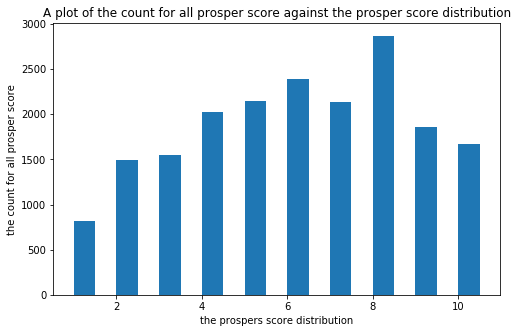

```python
binsize = .5
bins = np.arange(df1["ProsperScore"].min(),df1["ProsperScore"].max(), binsize)

plt.figure(figsize=[8, 5])
plt.hist(data = df1, x = 'ProsperScore', bins = bins)
plt.title("A plot of the count for all prosper score against the prosper score distribution")
plt.xlabel("the prospers score distribution")
plt.ylabel("the count for all prosper score");
plt.show()
```

> I observed from this that though the highest count for prosper score was 8 the avarage shifted more towards the left/lower prosper score which is indicative of a higher number of distribution of prosper scores on the lower end of the distribution

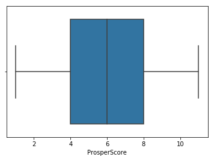

```python
sb.boxplot(data = df1 , x = "ProsperScore");
```

> This was further buttressed by this box plot

```python
df1["ProsperScore"].value_counts()
```

```
8.0     2867
6.0     2390
5.0     2146
7.0     2137
4.0     2020
9.0     1863
10.0    1673
3.0     1546
2.0     1494
11.0     823
1.0      812
Name: ProsperScore, dtype: int64
```

> most borrowers have a prosper score of 8, or borrowers with prosper score of 8 are significantlty high, followed closely by borrowers with 6. However although the borrowers with prosper score of 8 appears to be more but the The average prosper score is 6.0. Thus checking the value counts, it shows that the prosper scores with 6 and bellow have more distribution of borrowers than higher prosper scores of 8.0 and upwards

> To further back this assertion I will be plotting a value count for the prosper score

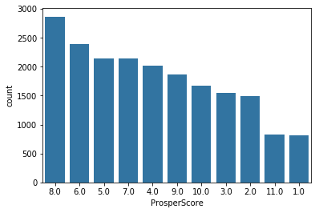

```python
labels = df1["ProsperScore"].value_counts().index
color_fav = sb.color_palette()[0]
sb.countplot(data = df1 , x = "ProsperScore", color=color_fav, order=labels);
```

> Ordering this we see a clear plot showing more of the distribution is on the lower end of the distribution

Next up, the first predictor variable of interest: Employment status of the people who take the most loans for a categorical analysis.

For the purpose of this we will be comparing and ploting the number of borrowers against their employment statuses

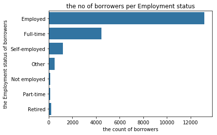

```python
sb.countplot(data = df1, y = "EmploymentStatus", color= color_fav);
plt.title("the no of borrowers per Employment status")
plt.ylabel("the Employment status of borrowers")
plt.xlabel("the count of borrowers");
```

> There were more loans given to people who were employed with a higher frequency for full-time staff, and self employed people. this may hit to a bias by the firms towards some sort of income frequency

Checking the available inputs for the loan status

```python
Loanstatus_counts = df1["LoanStatus"].value_counts()
Loanstatus_counts.index
```

```
Index(['Current', 'Completed', 'Chargedoff', 'Defaulted',
       'Past Due (1-15 days)', 'Past Due (61-90 days)',
       'Past Due (91-120 days)', 'Past Due (31-60 days)',
       'Past Due (16-30 days)', 'FinalPaymentInProgress',
       'Past Due (>120 days)'],
      dtype='object')
```

Streamlining for the inputs required for the top 5 statuses

```python
Loanstatus_counts = df1["LoanStatus"].value_counts()[:5]
Loan_index = Loanstatus_counts.index
Loan_index
```

```
Index(['Current', 'Completed', 'Chargedoff', 'Defaulted',
       'Past Due (1-15 days)'],
      dtype='object')
```

Plotting a pie chart for this analysis to take graphical form

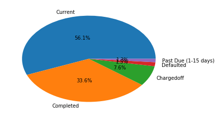

```python
plt.pie(Loanstatus_counts, labels = Loan_index , pctdistance=.5 , autopct= "%.1f%%");
```

```python
IncomeRange_count = df1["IncomeRange"].value_counts()
IncomeRange_index = IncomeRange_count.index
IncomeRange_index
```

```
Index(['$50,000-74,999', '$25,000-49,999', '$100,000+', '$75,000-99,999',
       '$1-24,999', 'Not employed', '$0'],
      dtype='object')
```

Plotting a pie chart to analyse the income ranges

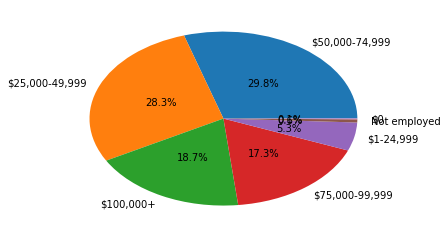

```python
plt.pie(IncomeRange_count, labels = IncomeRange_index , pctdistance=.5 , autopct= "%.1f%%");
```

```python
def cat_plot(var):
    label = df1[var].value_counts().index
    sb.countplot(data = df1, y = var, color= color_fav, label = label);
    plt.title(f"the no of loans per {var}")
    plt.ylabel(f"the {var} of borrowers")
    plt.xlabel("the count of borrowers")
```

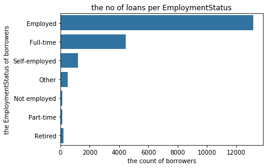

```python
cat_plot("EmploymentStatus")
```

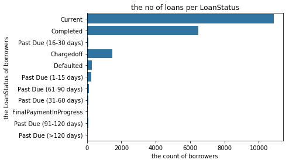

```python
cat_plot("LoanStatus")
```

```python
df1.columns
```

```
Index(['LoanStatus', 'LenderYield', 'ProsperRating (numeric)', 'ProsperScore',
       'ListingCategory (numeric)', 'Occupation', 'EmploymentStatus',
       'IsBorrowerHomeowner', 'CurrentDelinquencies', 'AmountDelinquent',
       'DelinquenciesLast7Years', 'IncomeRange', 'TotalProsperLoans',
       'OnTimeProsperPayments', 'BorrowerState'],
      dtype='object')
```

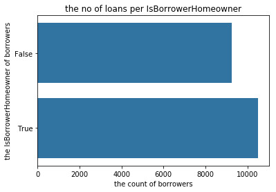

```python
cat_plot("IsBorrowerHomeowner")
```

> A larger percentage of borrowers owned homes which is indicative of them thinking they have enough backing or collateral to pay back the loan

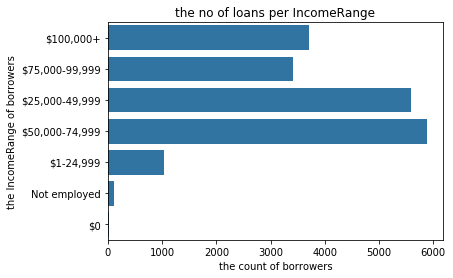

```python
cat_plot("IncomeRange")
```

People with an income range of 25k-80k had a higher number of loans taken out by them, while those in higher income ranges and more lower income ranges took out less loans indicative of them being able to fund their lifestyles as is

```python
def Univarate_plot():
    plt.figure(figsize= [30,8])

    plt.subplot(1,5,1)
    plt.hist(data = df1 , x = "ProsperScore" , bins = bins)
    plt.xlabel("the prospers score distribution")
    plt.ylabel("the count for all prosper score")

    plt.subplot(1,5,2)
    labels = df1["ProsperScore"].value_counts().index
    color_fav = sb.color_palette()[0]
    sb.countplot(data = df1 , x = "ProsperScore", color=color_fav, order=labels)

    plt.subplot(1,5,3)
    sb.countplot(data = df1, y = "EmploymentStatus", color= color_fav);
    plt.title("the no of loans per Employment status")
    plt.ylabel("the Employment status of borrowers")
    plt.xlabel("the count of borrowers")
    plt.yticks(rotation =90)

    plt.subplot(1,5,4)
    Loanstatus_counts = df1["LoanStatus"].value_counts()[:5]
    Loan_index = Loanstatus_counts.index
    plt.pie(Loanstatus_counts, labels = Loan_index , pctdistance=.5 , autopct= "%.1f%%")
    plt.title("The most no of loans based on LoanStatus");

    plt.subplot(1,5,5)
    IncomeRange_count = df1["IncomeRange"].value_counts()[:5]
    IncomeRange_index = IncomeRange_count.index
    plt.pie(IncomeRange_count, labels = IncomeRange_index , pctdistance=.5 , autopct= "%.1f%%")
    plt.title("The most percentage of loans given based on income range bracket");
```

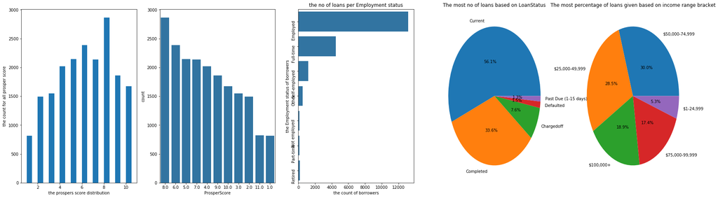

```python
Univarate_plot()
```

### Discuss the distribution(s) of your variable(s) of interest. Were there any unusual points? Did you need to perform any transformations?

most borrowers have a prosper score of 8, or borrowers with prosper score of 8 are significantlty high, followed closely by borrowers with 6. However although the borrowers with prosper score of 8 appears to be more but the The average prosper score is 6.0. Thus checking the value counts, it shows that the prosper scores with 6 and bellow have more distribution of borrowers than higher prosper scores of 8.0 and upwards.

There were more loans given to people who were employed with a higher frequency for full-time staff, and self employed people. this may hit to a bias by the firms towards some sort of income frequency.

More than half the loans are current with a large percentage being completed followed by the percentage that having been charged off.

People with an income range of 50k-80k had a higher number of loans taken out by them.

For all the analysis, I had to perform a value count and define an index so as to produce the plot required for the analysis.

## Bivariate Exploration

I will be looking to analyse the correlations of each items

Analysing using heat maps plots

```python
df1_corr = df1.corr()
df1_corr
```

|  | LenderYield | ProsperRating (numeric) | ProsperScore | ListingCategory (numeric) | IsBorrowerHomeowner | CurrentDelinquencies | AmountDelinquent | DelinquenciesLast7Years | TotalProsperLoans | OnTimeProsperPayments |
| --- | --- | --- | --- | --- | --- | --- | --- | --- | --- | --- |
| LenderYield | 1.000000 | -0.952346 | -0.754927 | -0.001722 | -0.103161 | 0.192588 | 0.058338 | 0.161547 | -0.053791 | 0.003134 |
| ProsperRating (numeric) | -0.952346 | 1.000000 | 0.757645 | -0.004901 | 0.116415 | -0.191651 | -0.058092 | -0.160661 | 0.046683 | -0.017253 |
| ProsperScore | -0.754927 | 0.757645 | 1.000000 | -0.027095 | 0.018841 | -0.180713 | -0.069149 | -0.134610 | 0.069698 | 0.060527 |
| ListingCategory (numeric) | -0.001722 | -0.004901 | -0.027095 | 1.000000 | -0.066313 | 0.042999 | 0.019100 | 0.048824 | -0.004084 | -0.019638 |
| IsBorrowerHomeowner | -0.103161 | 0.116415 | 0.018841 | -0.066313 | 1.000000 | 0.032854 | 0.067981 | 0.003413 | 0.016618 | 0.006046 |
| CurrentDelinquencies | 0.192588 | -0.191651 | -0.180713 | 0.042999 | 0.032854 | 1.000000 | 0.429208 | 0.421656 | 0.001249 | 0.045602 |
| AmountDelinquent | 0.058338 | -0.058092 | -0.069149 | 0.019100 | 0.067981 | 0.429208 | 1.000000 | 0.318133 | 0.001770 | 0.021627 |
| DelinquenciesLast7Years | 0.161547 | -0.160661 | -0.134610 | 0.048824 | 0.003413 | 0.421656 | 0.318133 | 1.000000 | -0.025969 | 0.012283 |
| TotalProsperLoans | -0.053791 | 0.046683 | 0.069698 | -0.004084 | 0.016618 | 0.001249 | 0.001770 | -0.025969 | 1.000000 | 0.702114 |
| OnTimeProsperPayments | 0.003134 | -0.017253 | 0.060527 | -0.019638 | 0.006046 | 0.045602 | 0.021627 | 0.012283 | 0.702114 | 1.000000 |

This is to give insight into the relationship that exist between two numerical columns

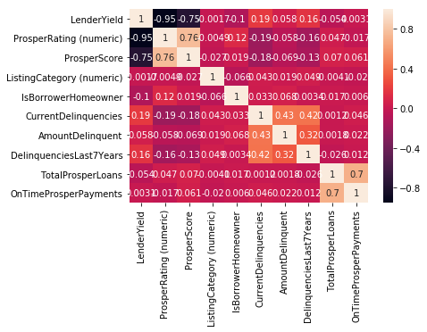

```python
sb.heatmap(df1_corr, annot=True );
```

To find from the map and the table the strong correlations, we need to see which adhere to the following rules

- strongly correlated = +-.6 <= +-.99
- averagely correlated = +-.4 <= +-.59
- slightly corelated = +- .3 <= +-.399
- lower correlated = .1 <= +-.3
- weak correlations <.1

Creating function loops to keep from repitition

```python
def reg_plot_func(a , b, x_jitter=0, y_jitter=0):
    '''
    docustring: This is a function that plots the numeric discrete variables against each other reducing the need for repitition
    input: numeric variable 1
    output: numeric variable 2
    '''

    #Set plot dimensions
    plt.figure(figsize=[14,6])
    sb.regplot (data = df1, x = a, y = b,x_jitter=x_jitter, y_jitter=y_jitter,
                scatter_kws={'s':1}, line_kws={'color': 'green'})
    plt.title(f'Relationship between {a} and {b}')
```

```python
def scat_plot_func(a, b):
    plt.scatter(data = df1 ,  x = a , y = b);
```

```python
def vio_plot_func(a , b):
    index_col = df1.groupby(a)[b].mean().sort_values(ascending = False).index
    plt.figure(figsize= [20, 5])
    color_fav = sb.color_palette()[0]
    sb.violinplot(data = df1 , x = a , y = b,color = color_fav , order = index_col)
    plt.xticks(rotation = 90);
```

```python
def box_plot_func(a , b):
    order_gr = df1.groupby(a)[b].mean().sort_values(ascending = False).index
    fav_color = sb.color_palette()[0]
    sb.boxplot(data = df1 , x = a , y  = b, color= fav_color, order=order_gr)
    plt.xticks(rotation = 90);
```

```python
def swa_plot_func(a , b):
    sb.swarmplot(data = df1 , x = a , y = b);
```

```python
def count_plot_func(a , b):
    sb.countplot(data = df1, x = a, y = b, color= color_fav);
    plt.title("the no of {a} per {b}")
    plt.ylabel("the {b} of borrowers")
    plt.xlabel("the {a} of borrowers")
    plt.yticks(rotation =90)
```

#### Plot of OnTimeProsperPayments against TotalProsperLoans

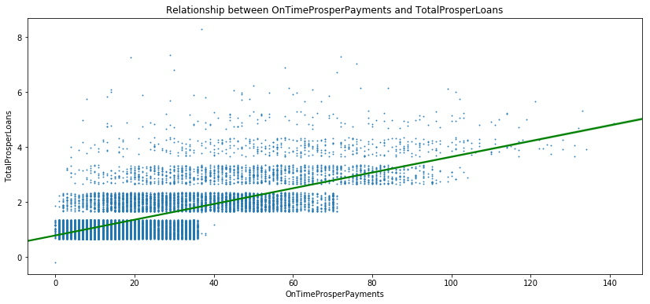

```python
reg_plot_func("OnTimeProsperPayments","TotalProsperLoans", y_jitter =0.35)
```

> There is a strong positive correlation between the ontime prosper payments and the total prosper loans gotten. this shows that more loans are given to people who pay back the loans on time and on schedule

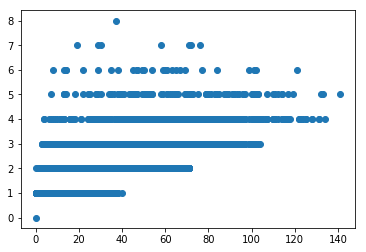

```python
scat_plot_func("OnTimeProsperPayments","TotalProsperLoans")
```

> There is further buttressed by this scatter plot

there is a strong relationshp between Totalprosperloans and onTimeProsperpayments

```python
df1.columns
```

```
Index(['LoanStatus', 'LenderYield', 'ProsperRating (numeric)', 'ProsperScore',
       'ListingCategory (numeric)', 'Occupation', 'EmploymentStatus',
       'IsBorrowerHomeowner', 'CurrentDelinquencies', 'AmountDelinquent',
       'DelinquenciesLast7Years', 'IncomeRange', 'TotalProsperLoans',
       'OnTimeProsperPayments', 'BorrowerState'],
      dtype='object')
```

#### Plot of "ProsperRating (numeric)" vs "ProsperScore" -reg plot

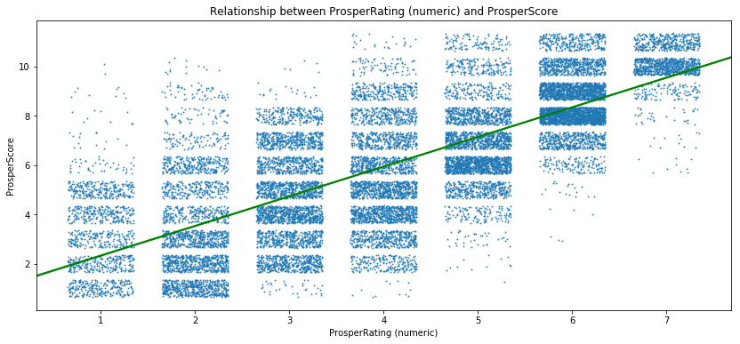

```python
reg_plot_func("ProsperRating (numeric)", "ProsperScore", x_jitter=0.35, y_jitter=0.35)
```

> There is also a strong positive correlation between the prosper rating and the prosper score of the individuals, this means that the higher your prosper score the higher rated you are which can translate to more loans

#### Plot of LoanStatus vs ProsperRating (numeric)" - box plot

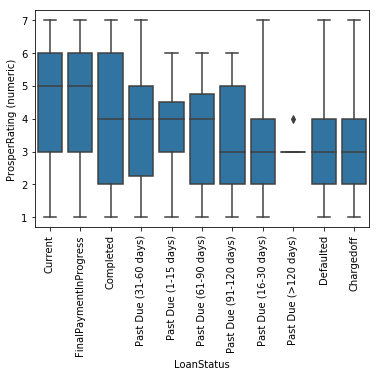

```python
box_plot_func("LoanStatus", "ProsperRating (numeric)")
```

> Loans that are still running or paid back on time tends to have a good prosper score than other loan statuses with defaulted and charged off loans earning the individual very low prosper ratings as such poor prosper scores

#### Plot of LoanStatus vs LenderYield - violin plot

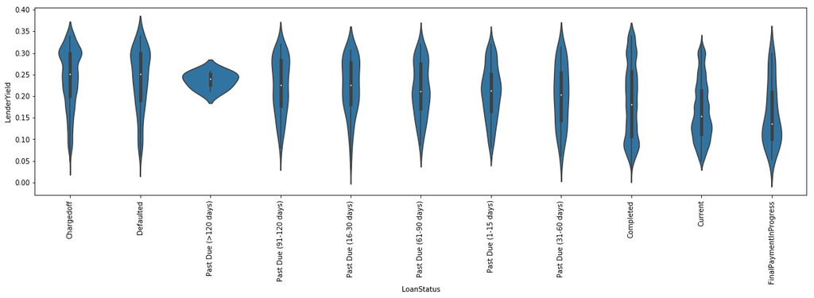

```python
vio_plot_func("LoanStatus", "LenderYield")
```

#### Plot of "ProsperRating (numeric)" vs "LenderYield"

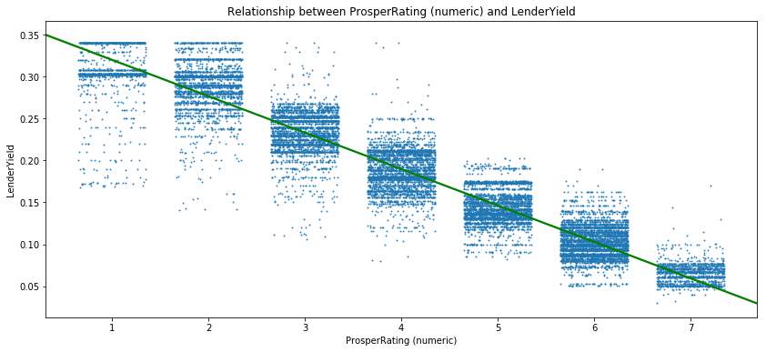

```python
reg_plot_func("ProsperRating (numeric)", "LenderYield", x_jitter=0.35)
```

> If a borrower has a good prosper score , this will have a negative effect on the lendersyield meaning the lender gains less from people with higher prosper rating as they tend to pay back thier loans on time and on schedule

#### Plot of EmploymentStatus vs TotalProsperLoans -swarmplot

```python
df1r = df1.iloc[np.random.choice(df1.shape[0],2500)]
df1r.columns
```

```
Index(['LoanStatus', 'LenderYield', 'ProsperRating (numeric)', 'ProsperScore',
       'ListingCategory (numeric)', 'Occupation', 'EmploymentStatus',
       'IsBorrowerHomeowner', 'CurrentDelinquencies', 'AmountDelinquent',
       'DelinquenciesLast7Years', 'IncomeRange', 'TotalProsperLoans',
       'OnTimeProsperPayments', 'BorrowerState'],
      dtype='object')
```

[figure not shown]

```python
sb.swarmplot(data = df1r , x= "EmploymentStatus" , y = "TotalProsperLoans" );
plt.xticks(rotation = 45);
```

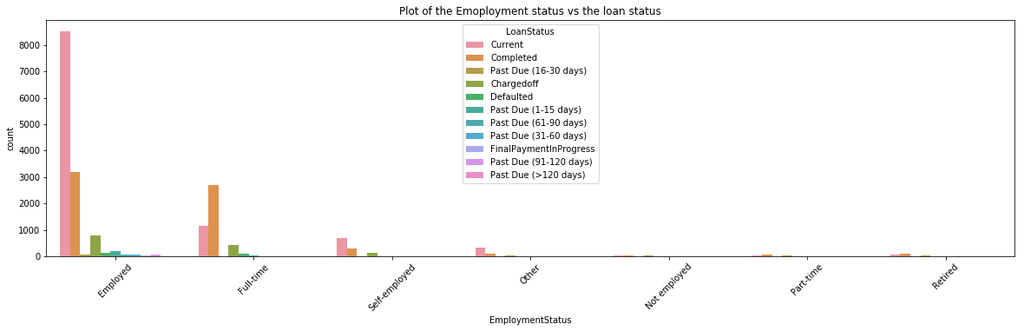

```python
plt.figure(figsize=[20,5])
sb.countplot(data =df1 , x = "EmploymentStatus" , hue="LoanStatus")
plt.title("Plot of the Emoployment status vs the loan status")
plt.xticks(rotation = 45);
```

```python
def Bivarate_plot():
    plt.figure(figsize= [40,50])

    plt.subplot(6,2,1)
    box_plot_func("LoanStatus", "ProsperRating (numeric)")
    plt.title("the loan status per prosper rating")
    plt.xlabel("the loan status of borrowers")
    plt.ylabel("the prosper rating")

    plt.subplot(6,2,2)
    sb.countplot(data =df1 , x = "EmploymentStatus" , hue="LoanStatus")
    plt.title("the employment status per loan status")
    plt.xticks(rotation = 45)
```

plt.figure?

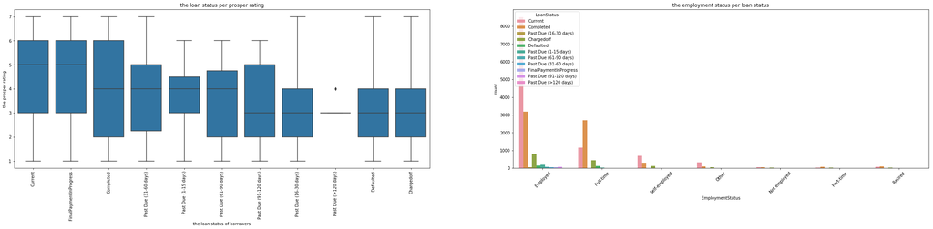

```python
Bivarate_plot()
```

It is noticed that the total prosper loans and count for ontime payment have a positive correlation meaning the higher one goes the higher the other

More pople with higher prosper ratings had their loan statuses current with final payment in progress for some while the ones with lower prosper ratings have their payments delayed or charged off

The prosper rating and the lender yield had a negative correlation meaning the lowerr the prosper rating the higher the lender yield

## Multivariate Exploration

```python
df1_corr
```

|  | LenderYield | ProsperRating (numeric) | ProsperScore | ListingCategory (numeric) | IsBorrowerHomeowner | CurrentDelinquencies | AmountDelinquent | DelinquenciesLast7Years | TotalProsperLoans | OnTimeProsperPayments |
| --- | --- | --- | --- | --- | --- | --- | --- | --- | --- | --- |
| LenderYield | 1.000000 | -0.952346 | -0.754927 | -0.001722 | -0.103161 | 0.192588 | 0.058338 | 0.161547 | -0.053791 | 0.003134 |
| ProsperRating (numeric) | -0.952346 | 1.000000 | 0.757645 | -0.004901 | 0.116415 | -0.191651 | -0.058092 | -0.160661 | 0.046683 | -0.017253 |
| ProsperScore | -0.754927 | 0.757645 | 1.000000 | -0.027095 | 0.018841 | -0.180713 | -0.069149 | -0.134610 | 0.069698 | 0.060527 |
| ListingCategory (numeric) | -0.001722 | -0.004901 | -0.027095 | 1.000000 | -0.066313 | 0.042999 | 0.019100 | 0.048824 | -0.004084 | -0.019638 |
| IsBorrowerHomeowner | -0.103161 | 0.116415 | 0.018841 | -0.066313 | 1.000000 | 0.032854 | 0.067981 | 0.003413 | 0.016618 | 0.006046 |
| CurrentDelinquencies | 0.192588 | -0.191651 | -0.180713 | 0.042999 | 0.032854 | 1.000000 | 0.429208 | 0.421656 | 0.001249 | 0.045602 |
| AmountDelinquent | 0.058338 | -0.058092 | -0.069149 | 0.019100 | 0.067981 | 0.429208 | 1.000000 | 0.318133 | 0.001770 | 0.021627 |
| DelinquenciesLast7Years | 0.161547 | -0.160661 | -0.134610 | 0.048824 | 0.003413 | 0.421656 | 0.318133 | 1.000000 | -0.025969 | 0.012283 |
| TotalProsperLoans | -0.053791 | 0.046683 | 0.069698 | -0.004084 | 0.016618 | 0.001249 | 0.001770 | -0.025969 | 1.000000 | 0.702114 |
| OnTimeProsperPayments | 0.003134 | -0.017253 | 0.060527 | -0.019638 | 0.006046 | 0.045602 | 0.021627 | 0.012283 | 0.702114 | 1.000000 |

#### Heat map indicative of the relationship between the numeric values in the data frame

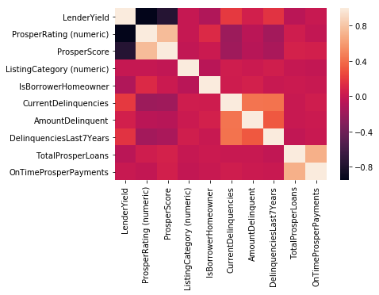

```python
sb.heatmap(df1.corr())
```

#### A plot taking the categorical input of of each of the employment status types when relating to ontime prosper payments and total prosper loans

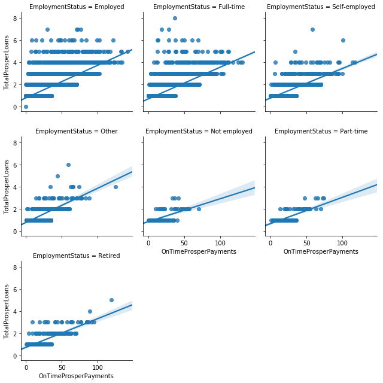

```python
g = sb.FacetGrid(data = df1 , col = "EmploymentStatus", col_wrap= 3)
g.map(sb.regplot, "OnTimeProsperPayments", "TotalProsperLoans")
```

> The strong positive correlation with the facet grid with the width still close to the corelation line shows that the relationship between all three is close and tight which shows that the Employment status can predict the strong correlation of on time prosper payment and the total prosper loans

```python
# numerical vs numerical vs numerical - plt.scatterplot(data =df3 , x = "", y= "", s ="")
# categorical(Loanstatus) vs 2 numerical (prosperRating (numeric)" vs "LenderYield) - 3 relationship - Facegrid
# categorical(EmploymentStatus) vs 2 numerical (prosperRating (numeric)" vs "LenderYield) - 3 relationship - Facegrid
#multi columns -- sb.heatmap() -- multiple columns
```

#### A plot taking the categorical input of of each of the loan status types when relating to total prosper loans

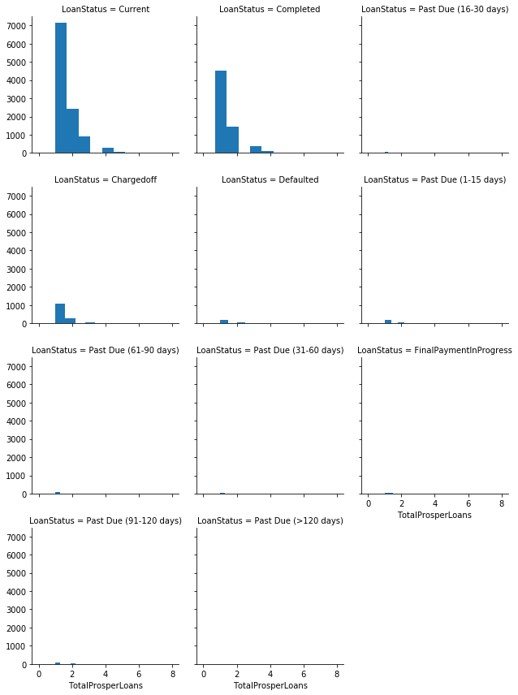

```python
plt.figure(figsize= [20,5])
g = sb.FacetGrid(data = df1 , col=  "LoanStatus", col_wrap= 3)
g.map(plt.hist, "TotalProsperLoans");
```

#### Plotting Prosper rating against prosper score and lender yeild

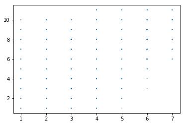

```python
plt.scatter(data =df1, x = "ProsperRating (numeric)", y= "ProsperScore", s = "LenderYield")
```

#### Plotting Employment status against prosper rating against lender yield

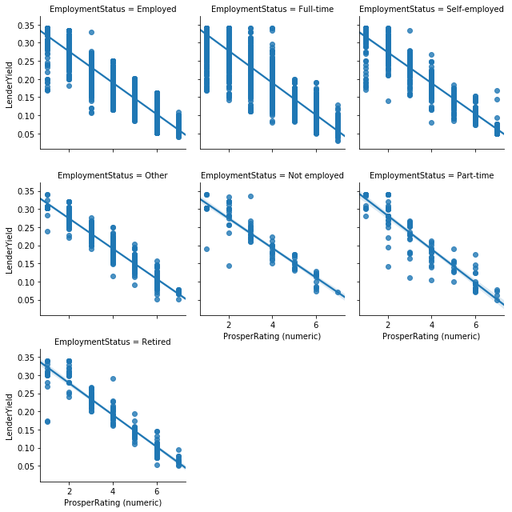

```python
g = sb.FacetGrid(data = df1 , col = "EmploymentStatus", col_wrap= 3)
g.map(sb.regplot, "ProsperRating (numeric)", "LenderYield")
```

> The strong negative correlation with the facet grid with the width still close to the corelation line shows that the relationship between all three is close and tight which shows that the Employment status can predict the strong correlation of on lender yield and prosper rating

#### Plotting loan status against prosper rating against lender yield

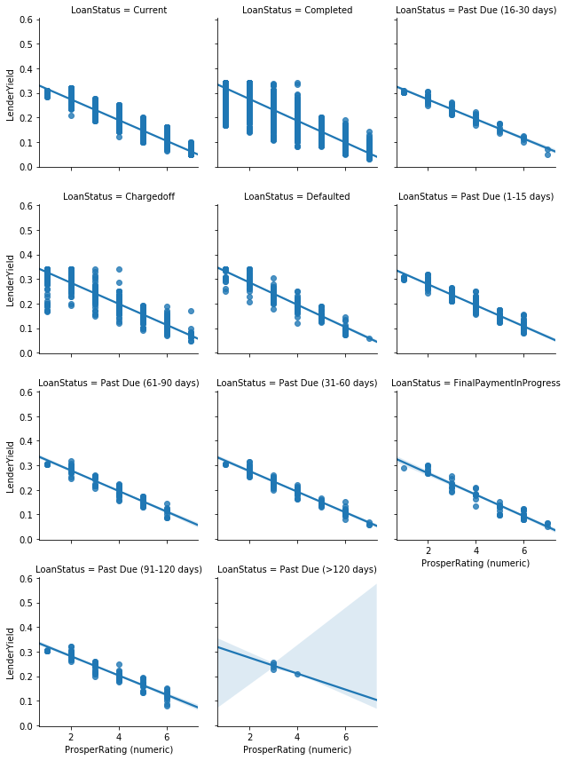

```python
g = sb.FacetGrid(data = df1 , col = "LoanStatus", col_wrap= 3)
g.map(sb.regplot, "ProsperRating (numeric)", "LenderYield")
```

#### Plotting Loan status against ontime prosper rating against Total prosper loans

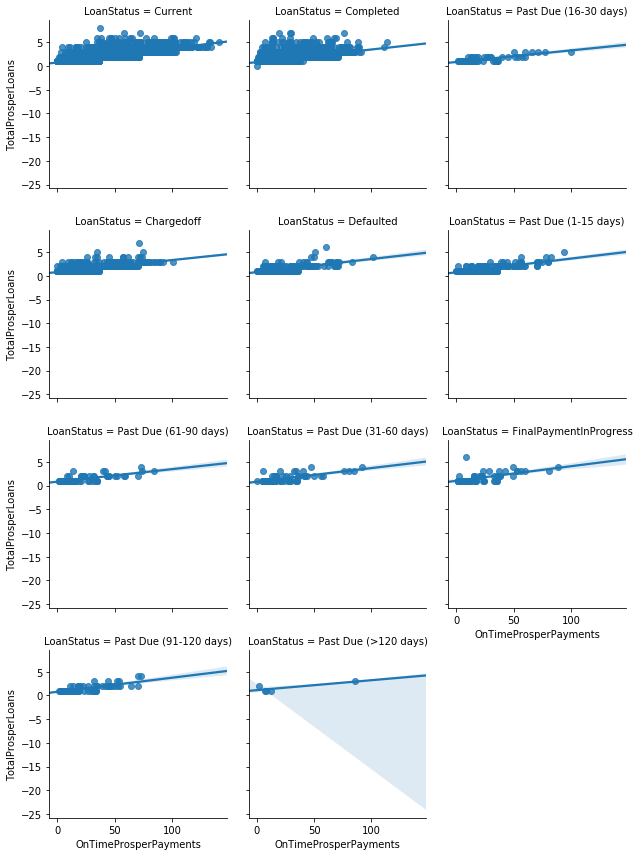

```python
g = sb.FacetGrid(data = df1 , col = "LoanStatus", col_wrap= 3)
g.map(sb.regplot, "OnTimeProsperPayments", "TotalProsperLoans")
```

```
plt.subplot(1,5,1)
sb.heatmap(df1.corr())
plt.title("Heat map of the numerical values")

plt.subplot(1,5,2)
plt.title("Employmentstaus column against ontime prosper rating against Total prosper loans")
g = sb.FacetGrid(data = df1 , col = "EmploymentStatus", col_wrap= 3)
g.map(sb.regplot, "OnTimeProsperPayments", "TotalProsperLoans")

plt.subplot(1,5,3)
plt.title("Employmentstaus column against prosper rating against LenderYield")
g = sb.FacetGrid(data = df1 , col = "EmploymentStatus", col_wrap= 3)
g.map(sb.regplot, "ProsperRating (numeric)", "LenderYield")

plt.subplot(1,5,4)
plt.title("Loanstaus column against prosper rating against LenderYield")
g = sb.FacetGrid(data = df1 , col = "LoanStatus", col_wrap= 3)
g.map(sb.regplot, "ProsperRating (numeric)", "LenderYield")

plt.subplot(1,5,5)
plt.title("Loan status against ontime prosper rating against Total prosper loans")
g = sb.FacetGrid(data = df1 , col = "LoanStatus", col_wrap= 3)
g.map(sb.regplot, "OnTimeProsperPayments", "TotalProsperLoans")
```

### Talk about some of the relationships you observed in this part of the investigation. Were there features that strengthened each other in terms of looking at your feature(s) of interest?

The heat map showed the correlation between all numeric values in the data frame

With refrence to the Employment status column, The "OnTimeProsperPayments" and the "TotalProsperLoans" showed a strong positive correlation rising with each other.

With refrence to the Employment status column, The "ProsperRating (numeric)" and the "LenderYield" showed a strong negatively inverse correlation

With refrence to the Loan status column, The "ProsperRating (numeric)" and the "LenderYield" showed a strong negatively inverse correlation

With refrence to the Loan status column, The "OnTimeProsperPayments" and the "TotalProsperLoans" showed a strong positive correlation rising with each other.

### Were there any interesting or surprising interactions between features?

The Employment ststus and and the Loan status Both have the similar effect on the numerical columns checked as they all showed the similar behaviours when checked against other columns

## Conclusions

I found out that Prosper ratings and lender yield wereb inversly correlated and were unaffected by when put against other columns. On time loan payment and Total prosper loans always seem to have a strong positive correlation in all cases